# ds202_lab2

Blake Inderski and Guang Yi Lim

February 12, 2019

```r
choco <-read.csv("https://xdaiisu.github.io/ds202materials/hwlabs/choco.csv")
#head(choco)
library(ggplot2)
```

**Team question set**

Q1 - What is the overall number of chocolate bars rated?

```r
ratingCount <- length(choco$Rating)
print(ratingCount)
```

```
## [1] 1852
```

1852 chocolate bars were rated.

Q2 - How does the number of ratings depend on the year? Draw a bar chart of the number of reports.

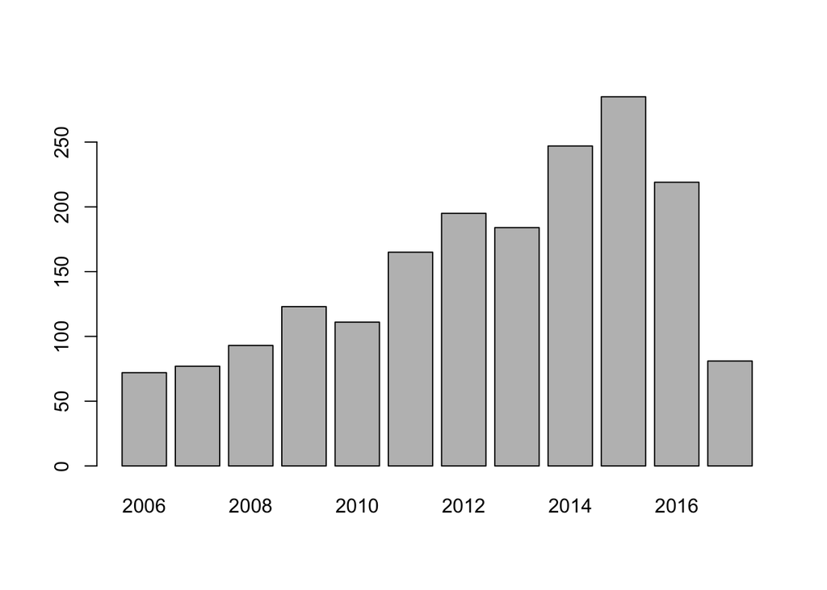

```r
dateTable <- table(choco$Review.Date)
barplot(dateTable)
```

Number of ratings is skewed left.

Q3 - How do ratings compare across different company locations? Focus on the three locations with the most ratings. (Hint: They are U.S.A., France, and Canada, but find them out using codes.)

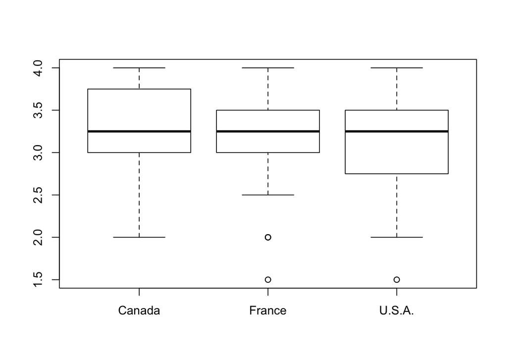

```r
location_df <- data.frame(table(choco$Company.Location))
sortRating <- location_df[order(-location_df$Freq), ][1:3, ] #three countries with most ratings
top3 <- as.matrix(sortRating$Var1)
extract3 <- choco[choco$Company.Location %in% top3, ]
extract3 <- droplevels(extract3)
rating_v_location <- boxplot(Rating ~ Company.Location, data = extract3)
```

```r
rating_v_location$stats
```

```
##      [,1] [,2] [,3]
## [1,] 2.00 2.50 2.00
## [2,] 3.00 3.00 2.75
## [3,] 3.25 3.25 3.25
## [4,] 3.75 3.50 3.50
## [5,] 4.00 4.00 4.00
```

```r
#ggplot(extract3, aes(x=Company.Location, y=Rating)) + geom_boxplot()
aggregate(Rating ~ Company.Location, data = extract3, mean)
```

```
##   Company.Location   Rating
## 1           Canada 3.312500
## 2           France 3.253165
## 3           U.S.A. 3.162325
```

Median ratings for the top 3 (Canada, France, USA) is equal at 3.25. Canada has the highest mean rating (3.31), followed by France (3.25), and then U.S.A. (3.16).

Q4 - Brainstorm and write down an interesting question that can be answer from the dataset. The question should not duplicate the questions above.

What is the most prevalent bean type used for making chocolage bars?

Q5 - Answer the question from the dataset.

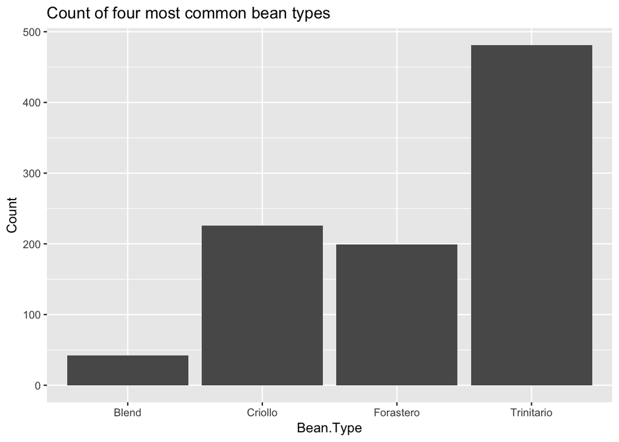

```r
bean_type <- as.matrix(choco$Bean.Type)
labeled_bean <- bean_type[bean_type != ""]
total_labeled_bean <- c()
for (str in labeled_bean) {
  split_values <- strsplit(str, '\\s+')[[1]]
  for (value in split_values) {
    if (grepl("\\(|\\)", value) == FALSE) { #disregard values in brackets
      value_sub <- gsub("\\,", "", value) #split labels with multiple values (comma separated)
      total_labeled_bean <- c(total_labeled_bean, c(value_sub))
    }
  }
}
#print(length(labeled_bean))
#print(length(total_labeled_bean))
bean_df <- data.frame(table(total_labeled_bean))
sort_bean <- droplevels(bean_df[order(-bean_df$Freq), ][1:4, ])
ggplot(sort_bean, aes(x=total_labeled_bean, y=Freq)) + geom_bar(stat="identity") +
  xlab("Bean.Type") +
  ylab("Count") +
  ggtitle("Count of four most common bean types")
```

Trinitario was the most common bean type, comprising nearly half of all recorded beans used for chocolate bars. The other two most common bean types were Forastero and Criollo. Other bean types seemed to be given vauge labels and often had low counts. An example of a vauge label was the fourth most common bean type label, Blend.